# Projet 2024 M2 ISF

## **4.3 Hypothèses**

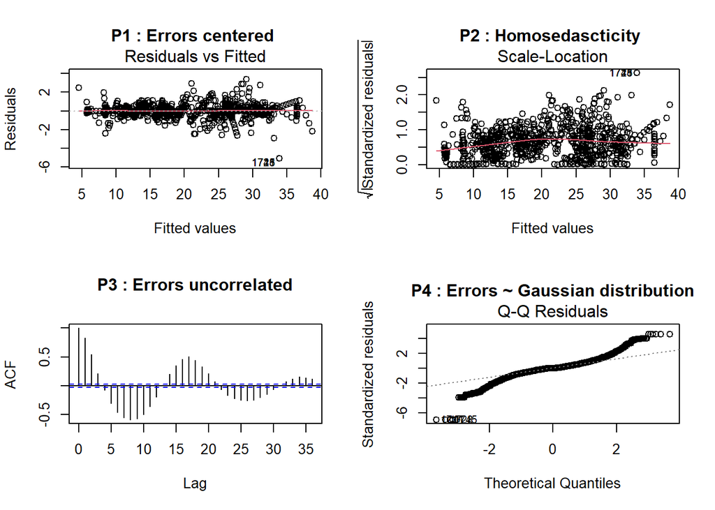

## **4.5 Predictions**

Calculons dans un premier temps le RMSE final sur l’ensemble du train :

```
## RMSE ensemble jeu de données :  0.7454577
```

Notre RMSE sur l’ensemble du jeu de train global est meilleur que notre RMSE de validation et moins bon que celui de notre set d’apprentissage, chose normale car nous avons séparer nos jeu de données entre avant et après le changement de tendance dans les durées vs scores. Sortons désormais les prédictions de notre modèle :

```r
hat_y<-as.data.frame(predict(mod_Final,newdata=testX))
colnames(hat_y) <- c("hat_y")
#write_csv(hat_y,'hat_y.csv')
```

# **5. Modèles complémentaires**

Dans cette partie nous explorons d’autres pistes que les modèles précédemments implémantés. Egalement dans un soucis de comparaison aux modèles linéaires sans interactions, nous gardons les varibles bruts sans intégrer de variables supplémentaires liées à des interactions.

## **5.1 Modèle fit pour chaque sujet**

Nous l’avons montré plusieurs fois, que le sujet jouait un rôle important dans la prédiction de score. Une idée naïve pourrait être alors de construire un modèle pour chaque sujet, et faire des predictions pour un sujet, son modèle associé. En faisant de la sorte, nous calculons un RMSE pour chaque sujet et faisons la moyenne pour un obtenir un RMSE global. Nous obtenons dès lors les résultats suivants :

```
## RMSE train :  0.05278624
```

```
## RMSE validation :  0.8669007
```

Nous pouvons remarquer une très nette amélioration de notre RMSE comparé aux autres modèles classiques !

## **5.2 Random forest**

Cette fois-ci nous testons un modèle global pour tous les sujets avec un random forest.

```r
set.seed(2023)
bestmtry <- tuneRF(x = predictors_train, y = target_train, stepFactor=1.5, improve=1e-5, ntree=500)
```

```
## mtry = 19  OOB error = 0.7894184
## Searching left ...
## mtry = 13    OOB error = 1.407535
## -0.783002 1e-05
## Searching right ...
## mtry = 28    OOB error = 0.4741713
## 0.399341 1e-05
## mtry = 42    OOB error = 0.3097512
## 0.3467525 1e-05
## mtry = 59    OOB error = 0.2843384
## 0.08204254 1e-05
```

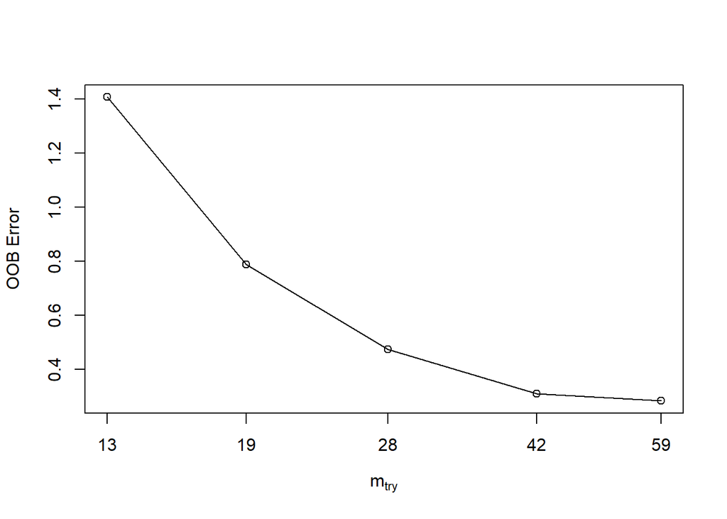

En tunant le random forest, nous trouvons que le nombre optimal de variables pour la construction de chaque arbre (mtry) est 59; soit le nombre maximal de variables possile (42 colonnes sujets + les autres variables). Construisons alors une forêt aléatoire avec ce paramètre et affichons l’importance des variables :

```r
set.seed(2023)
rf_model <- randomForest(x = predictors_train, y = target_train, importance = TRUE, mtry= 59)
```

```
## RMSE train :  0.202221
```

```
## RMSE validation :  1.045253
```

```r
predicted_scores_train <- predict(rf_model, newdata = matrix_train)
predicted_scores_validation <- predict(rf_model, newdata = matrix_validation)

importance(rf_model)
```

```
##             %IncMSE IncNodePurity
## sujet.1   31.041989    4246.12582
## sujet.2   14.693361    2109.37565
## sujet.3    9.698494     277.14917
## sujet.4   71.379682    4595.27431
## sujet.5   68.107050    9555.23803
## sujet.6   27.119951    2350.29063
## sujet.7   76.470460    3547.81597
## sujet.8   75.574649    2729.82443
## sujet.9   18.556730    1491.87092
## sujet.10  58.745717    5110.14937
## sujet.11  76.949327    2273.94864
## sujet.12  72.497135    2629.98369
## sujet.13  74.656096    3115.77182
## sujet.14  55.956681    6585.68332
## sujet.15  46.960988    4017.37614
## sujet.16  30.937066    7844.70512
## sujet.17  26.075951    1092.12981
## sujet.18 119.418422   17715.32295
## sujet.19  19.476407    1388.46339
## sujet.20  14.523902    2081.18295
## sujet.21  31.158517    3387.14403
## sujet.22  46.166954    5754.38325
## sujet.23  23.376080    2484.25948
## sujet.24  14.609947    2019.87354
## sujet.25   8.762630     184.64048
## sujet.26  31.919873    4388.05074
## sujet.27  15.998584    3025.51381
## sujet.28  47.659140    9028.51611
## sujet.29  24.283087    1097.97036
## sujet.30  35.241982    6360.74040
## sujet.31  33.672885    5954.17470
## sujet.32  63.686247    4891.58962
## sujet.33  11.959375     169.54522
## sujet.34  34.575905    4683.43617
## sujet.35  70.962661   20161.87372
## sujet.36  34.995449     631.84050
## sujet.37  22.120787    1549.67776
## sujet.38  68.680559    2228.53208
## sujet.39  17.142762    1026.23383
## sujet.40  72.210072    3213.29224
## sujet.41  72.436328   12858.72121
## sujet.42  48.413908     875.60814
## duree    196.710240    5571.75114
## FF         5.488170     131.86972
## FF.Abs    11.469314     481.91395
## FF.RAP     3.236308      44.95596
## FF.PPQ5    5.314939     177.34420
## FF.DDP     4.850085      57.80271
## AV         6.786555     176.64880
## AV.dB      5.340426     164.19052
## AV.APQ3    5.985168      63.44479
## AV.APQ5    5.064631     187.69854
## AV.APQ11   8.821178     359.02664
## AV.DDA     5.883511      73.81606
## BTC1       9.269327     306.93649
## BTC2      13.151577     779.14170
## CDNL      12.668729    2058.01756
## EFS       34.169318    8530.29769
## VFNL      13.799793     708.86126
```

Nous observons que via l’indice de Gini et le MSE que le modèle apporte **très peu d’importance** aux variables cliniques. Nous reconstruisons alors un random forest avec seulement **durée** et **sujet** comme variables et obtenons les résultats suivants :

```
## RMSE train :  0.007873212
```

```
## RMSE validation :  0.6306967
```

Nous observons alors une nette amélioration avec le train et le test.

## **5.3 XGBOOST**

Pour le XGBOOST nous lançons 100 rounds et nous arrêtons lorsque le modèle commence à overfit (early stopping), c’est à dire quand le RMSE de jeu de validation ne baisse plus.

```r
set.seed(2023)
df_xgboost <- bst$evaluation_log
df_xgboost_m <- melt(df_xgboost, na.rm = FALSE, value.name = 'value', id = 'iter')
```

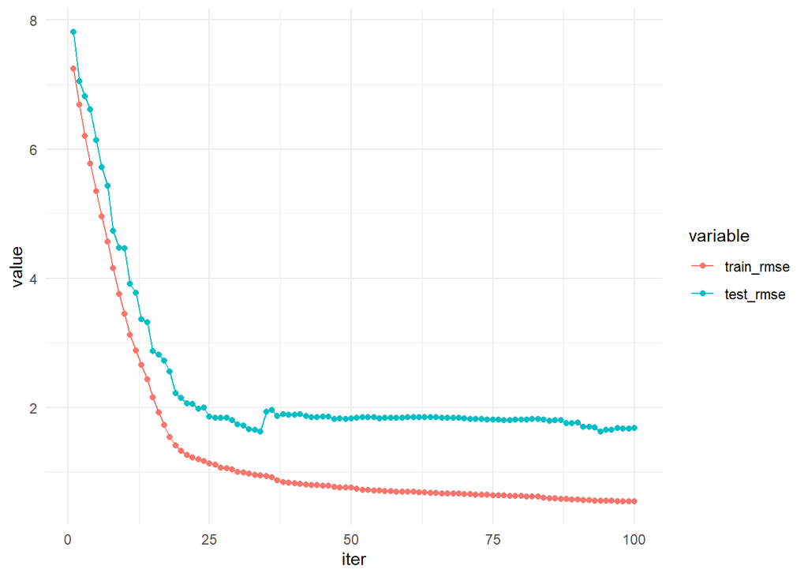

Le minimum de RMSE pour le set de validation est à l’époque 34, nous retenons ce modèle et obtenons les résultats :

```
## RMSE train :  0.9456108
```

```
## RMSE validation :  1.625535
```

## **5.4 Linear mixed effect model**

Enfin nous terminons en implémentant une autre catégorie de modèles : les modèles linéaires à effets aléatoires mixtes. Ces modèles sont spécialement adaptés pour notre type de dataset, lorsque plusieurs individus sont présents plusieurs fois à des instants différents, provoquant l’autocorrélation des résidus. Ces modèles permettent d’introduire une pente aléatoire propre à chaque sujet et donc de mieux généraliser la prédiction (sous condition d’avoir suffisamment d’observations pour chaque sujet).

```r
lme_1 <- lmer(score ~ duree + (1+ duree|sujet), data = apprentissage)
summary(lme_1)
```

```
## Linear mixed model fit by REML ['lmerMod']
## Formula: score ~ duree + (1 + duree | sujet)
##    Data: apprentissage
##
## REML criterion at convergence: -5260.5
##
## Scaled residuals:
##     Min      1Q  Median      3Q     Max
## -8.2888 -0.0090 -0.0001  0.0127  9.6266
##
## Random effects:
##  Groups   Name        Variance  Std.Dev. Corr
##  sujet    (Intercept) 65.917415 8.11895
##           duree        0.003265 0.05714  -0.21
##  Residual              0.007841 0.08855
## Number of obs: 3104, groups:  sujet, 42
##
## Fixed effects:
##              Estimate Std. Error t value
## (Intercept) 19.415675   1.252787  15.498
## duree        0.020497   0.008817   2.325
##
## Correlation of Fixed Effects:
##       (Intr)
## duree -0.209
```

Dans ce modèle simpliste avec seulement la *durée* et le *sujet*, nous avons rajouter une pente et un intercept random.

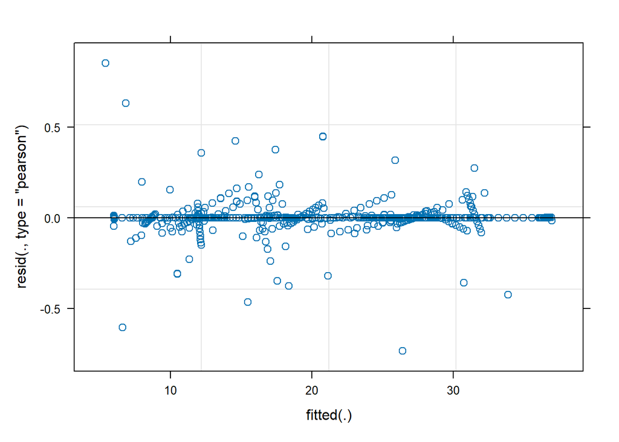

En affichant nous voyons bien que les résultats sont améliorés comparé à un modèle linéaire classique sans ajouts de variables. Pour le RMSE nous obtenons :

```
## RMSE train :  0.08734053
```

```
## RMSE validation :  1.172284
```

Tout comme nos autres modèles, nous pouvons augmenter le degrès via des interactions, par exemple de cette manière :

```r
lme_2 <- glmer(score ~ poly(duree, 2) + (1 + poly(duree, 2) | sujet), data = apprentissage)
```

```
## RMSE train :  0.06617856
```

```
## RMSE validation :  1.044641
```

Notons qu’ayant réduit l’autocorrélation, celle-ci reste toujours présente :

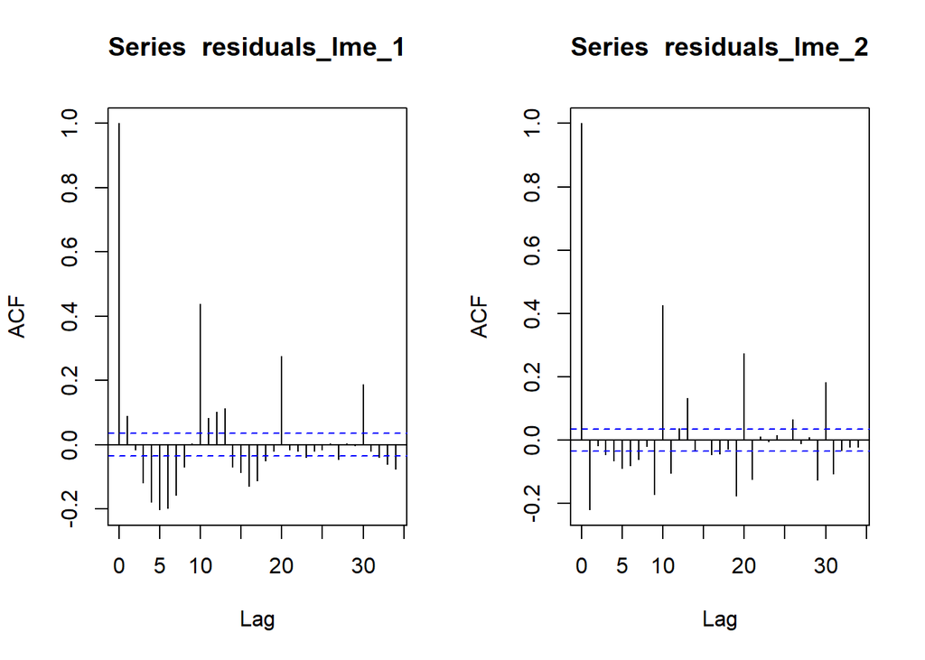

## **5.5 Bilan modèle et évaluation set de test**

| Modèle | RMSE_train | RMSE_validation |
| --- | --- | --- |
| LM fit par sujet | 0.052786243 | 0.8669007 |
| Random forest | 0.007873212 | 0.6306967 |
| xgboost | 0.945610821 | 1.6255345 |
| LME | 0.087340532 | 1.1722845 |
| LME deg. 2 | 0.066178565 | 1.0446413 |

Nous voyons que le meilleur modèle est le modèle random forest, ce sera donc le modèle retenu parmi nos modèles complémentaires. Nous justifions ce choix d’une part par les performances, mais aussi sa simplicité d’implémentation comparé par exemple au modèle fittant par sujet. Pour finir, évaluons nos 2 modèles retenus, à savoir le modèle linéaire avec interaction et le random forest sur le *set de test* :

```
## RMSE interaction sur le jeu de test :  3.076669
```

```
##
## RMSE random forest sur le jeu de test :  1.739938
```

Encore une fois, ces scores de RMSE montrent bien le changement de tendance dans le jeu données. Ces RMSE peuvent être interpretrer comme l’*erreur moyenne* attendu si nos modèles finaux n’étaient entrainés que sur la première portion des données (70 %). Pour cette raison, il est important pour nos modèles finaux d’être entrainer sur l’ensemble du jeu de données (et pas non plus sur la dernière portion des données voire les explications du bilan partie 3)!

## **5.5 Predictions**

Comme vu juste avant, pour la prediction, nous nous entrainons sur tout le jeu de données et pas seulement apprentissage :

```r
train_final_one <- train_final[,c("duree","sujet", "score")]
train_final_one<- dummyVars(" ~.", data = train_final_one)
train_final_one <- data.frame(predict(train_final_one, newdata = train_final))

predictors_train_final <- train_final_one[, !names(train_final_one) %in% "score"]
target_train_final <- train_final_one$score

rf_model_final <- randomForest(x = predictors_train_final, y = target_train_final, importance = TRUE, mtry= 43)
```

```r
hat_y_rf<-as.data.frame(predict(rf_model_final, newdata=matrix_real_test))
colnames(hat_y_rf) <- c("hat_y_rf")

combined_df <- cbind(hat_y, hat_y_rf)

write_csv(combined_df,'hat_y.csv')
```

# **6. Conclusion**

En conclusion de ce projet, nous avons vu via l’analyse descriptive que notre jeu de donnée était un *panel dataset*, caractérisé par la présence de plusieurs individus à des instants T différents. Nous avons également relevé le caractère spécifique de la variable **sujet** et son influence sur le score.  
En construisant plusieurs modèles linéaires avec différentes lois (Gaussien, Gamma, …) et seulement avec les variables disponibles, il est clair qu’il n’est pas possible de prédire correctement les scores. D’une part en regardant les performances, mais aussi car les hypothèses sous-jacentes aux modèles ne sont pas respectées.

Nous nous sommes alors tournés vers d’autres solutions comme la construction de nouvelles variables issues d’interactions entre les variables originelles (**duree** et **sujet**). Bien que cette méthode augmente les performances, certaines hypothèses ne sont toujours pas respectées. Enfin en élargant nos possibilitées à d’autres modèles pouvant capter des relations non linéaires type random forest, xgboost nous avons pu obtenir des résultats satisfaisants sans avoir à utiliser des interactions.

Notre conclusion sur cette étude est qu’il n’est pas possible de prédire les scores avec les variables cliniques disponibles sans prendre en considération le **sujet**. Même en utilisant cette variable, il nous faut aussi faire attention au choix de modèle que l’on utilise.

Parmi les orientations futures de cette étude, nous pouvons mentionner l’exploration plus profonde de modèle adapté pour le forecasting (modèles ARIMA, RNN, …) dont la recherche de minimisation de l’autocorrélation est le principal objectif. Egalement, la recherce de variables cliniques plus pertinentes.

Enfin rappelons que nous avons supposé le jeu de données comme propre et sans erreurs, malgré le fait que nous ayons relevé certains éléments (comme des durées négatives ou des duplicatas de sujets à la même durée) qui mériteraient une exploration plus profonde et une discussion avec des gens du métier.

# 7. **Annexes**

## **Vérification des conditions d’application GLM Gamma**

**Analyse de la mutlicolinéarité**

```
##            GVIF Df GVIF^(1/(2*Df))
## sujet 11.568069 41        1.030307
## duree  1.029289  1        1.014539
## BTC2   2.958823  1        1.720123
## EFS    4.850129  1        2.202301
```

**Analyse des outliers**

Affichons tout d’abord la distance de Cook pour chaque individu :

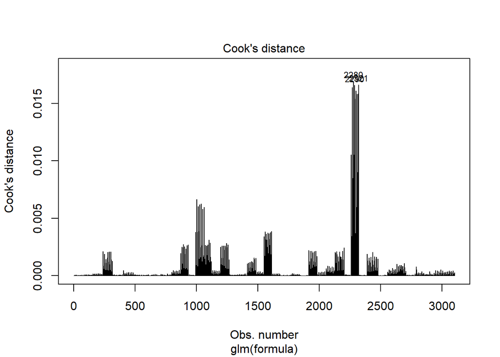

Nous observons qu’aucune des observations a une influence significative sur les coefficients du modèle.

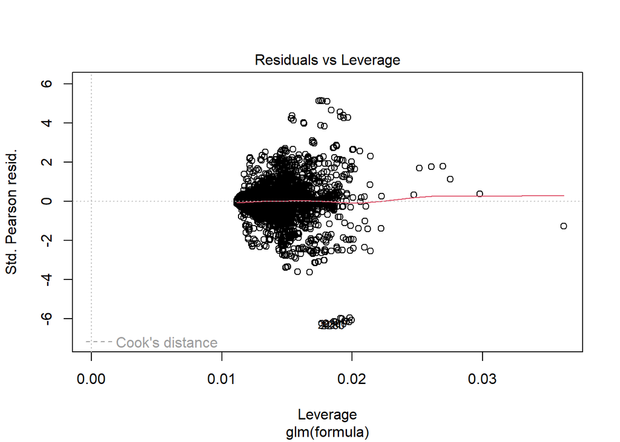

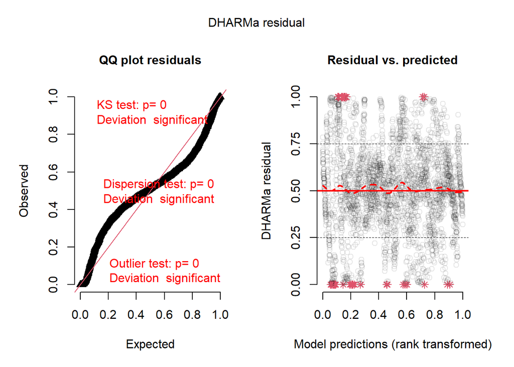

Ces graphiques peuvent indiquer plusieurs choses : ou bien notre modèle est trop complexe par rapport à la variation observée dans les données. Ou bien cela est peut-être due à la non-indépendance des données, notamment l’autocorrélation temporelle. Nous devons vérifier que notre modèle n’est pas surajusté aux tendances temporelles ou à d’autres structures de dépendance dans les données.

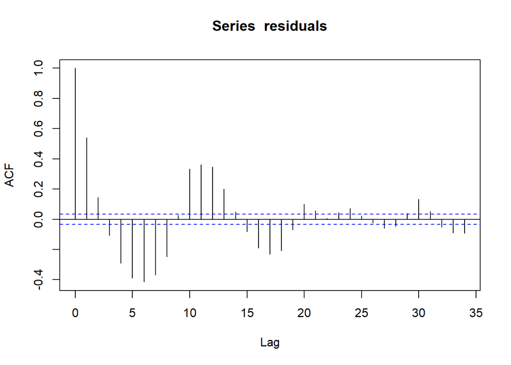

On voit de nombreuses bars dépasser le seuil. Nous avons la confirmation d’une autocorrélation dans les résidus. Nous pouvons donc bien conclure que les GLM ne sont pas adaptés pour ce type de dataset.